# Examen minería datos I

Ricardo Alcañiz Frutos

10 de julio de 2019

## 1. Análisis gráfico y resumen de la información

## 1.1. Carga de los datos y estadísticas generales

Cargamos los datos y eliminamos la variable cliente, ya que no va a jugar ningún papel en el análisis. Mostramos las estadísticas generales de las variables.

```r
library(caret)
library(tidyverse)
library(data.table)
library(ggpubr)
library(doParallel)
library(dummies)
library(MASS)
library(Boruta)
library(sampling)
```

```r
library(corrplot)
library(ROCR)
library(pROC)
market_data <- read.csv("C:/Users/ricar/OneDrive/Documentos/Examen Minería Datos I/36005534-datos_examen_recuperacion_modulo_5_2019.csv")

market_data$Customer <- NULL

market_data_dt <- as.data.table(market_data)


str(market_data_dt)
```

```
## Classes 'data.table' and 'data.frame':   9134 obs. of  23 variables:
##  $ State                        : Factor w/ 5 levels "Arizona","California",..: 5 1 3 2 5 4 4 1 4 4 ...
##  $ Customer.Lifetime.Value      : num  2764 6980 12887 7646 2814 ...
##  $ Response                     : Factor w/ 2 levels "No","Yes": 1 1 1 1 1 2 2 1 2 1 ...
##  $ Coverage                     : Factor w/ 3 levels "Basic","Extended",..: 1 2 3 1 1 1 1 3 1 2 ...
##  $ Education                    : Factor w/ 5 levels "Bachelor","College",..: 1 1 1 1 1 1 2 5 1 2 ...
##  $ Effective.To.Date            : Factor w/ 59 levels "1/1/11","1/10/11",..: 48 25 42 13 53 18 48 10 19 40 ...
##  $ EmploymentStatus             : Factor w/ 5 levels "Disabled","Employed",..: 2 5 2 5 2 2 2 5 3 2 ...
##  $ Gender                       : Factor w/ 2 levels "F","M": 1 1 1 2 2 1 1 2 2 1 ...
##  $ Income                       : int  56274 0 48767 0 43836 62902 55350 0 14072 28812 ...
##  $ Location.Code                : Factor w/ 3 levels "Rural","Suburban",..: 2 2 2 2 1 1 2 3 2 3 ...
##  $ Marital.Status               : Factor w/ 3 levels "Divorced","Married",..: 2 3 2 2 3 2 2 3 1 2 ...
##  $ Monthly.Premium.Auto         : int  69 94 108 106 73 69 67 101 71 93 ...
##  $ Months.Since.Last.Claim      : int  32 13 18 18 12 14 0 0 13 17 ...
##  $ Months.Since.Policy.Inception: int  5 42 38 65 44 94 13 68 3 7 ...
##  $ Number.of.Open.Complaints    : int  0 0 0 0 0 0 0 0 0 0 ...
##  $ Number.of.Policies           : int  1 8 2 7 1 2 9 4 2 8 ...
##  $ Policy.Type                  : Factor w/ 3 levels "Corporate Auto",..: 1 2 2 1 2 2 1 1 1 3 ...
##  $ Policy                       : Factor w/ 9 levels "Corporate L1",..: 3 6 6 2 4 6 3 3 3 8 ...
##  $ Renew.Offer.Type             : Factor w/ 4 levels "Offer1","Offer2",..: 1 3 1 1 1 2 1 1 1 2 ...
##  $ Sales.Channel                : Factor w/ 4 levels "Agent","Branch",..: 1 1 1 3 1 4 1 1 1 2 ...
##  $ Total.Claim.Amount           : num  385 1131 566 530 138 ...
##  $ Vehicle.Class                : Factor w/ 6 levels "Four-Door Car",..: 6 1 6 5 1 6 1 1 1 1 ...
##  $ Vehicle.Size                 : Factor w/ 3 levels "Large","Medsize",..: 2 2 2 2 2 2 2 2 2 2 ...
##  - attr(*, ".internal.selfref")=<externalptr>
```

```r
summary(market_data_dt)
```

```
##         State      Customer.Lifetime.Value Response       Coverage
##  Arizona   :1703   Min.   : 1898           No :7826   Basic   :5568
##  California:3150   1st Qu.: 3994           Yes:1308   Extended:2742
##  Nevada    : 882   Median : 5780                      Premium : 824
##  Oregon    :2601   Mean   : 8005
##  Washington: 798   3rd Qu.: 8962
##                    Max.   :83325
##
##                 Education    Effective.To.Date      EmploymentStatus
##  Bachelor            :2748   1/10/11: 195      Disabled     : 405
##  College             :2681   1/27/11: 194      Employed     :5698
##  Doctor              : 342   2/14/11: 186      Medical Leave: 432
##  High School or Below:2622   1/26/11: 181      Retired      : 282
##  Master              : 741   1/17/11: 180      Unemployed   :2317
##                              1/19/11: 179
##                              (Other):8019
##  Gender       Income       Location.Code   Marital.Status
##  F:4658   Min.   :    0   Rural   :1773   Divorced:1369
##  M:4476   1st Qu.:    0   Suburban:5779   Married :5298
##           Median :33890   Urban   :1582   Single  :2467
##           Mean   :37657
##           3rd Qu.:62320
##           Max.   :99981
##
##  Monthly.Premium.Auto Months.Since.Last.Claim
##  Min.   : 61.00       Min.   : 0.0
##  1st Qu.: 68.00       1st Qu.: 6.0
##  Median : 83.00       Median :14.0
##  Mean   : 93.22       Mean   :15.1
##  3rd Qu.:109.00       3rd Qu.:23.0
##  Max.   :298.00       Max.   :35.0
##
##  Months.Since.Policy.Inception Number.of.Open.Complaints
##  Min.   : 0.00                 Min.   :0.0000
##  1st Qu.:24.00                 1st Qu.:0.0000
##  Median :48.00                 Median :0.0000
##  Mean   :48.06                 Mean   :0.3844
##  3rd Qu.:71.00                 3rd Qu.:0.0000
##  Max.   :99.00                 Max.   :5.0000
##
```

[output cut: 9 more lines]

```
##  Offer1:3752      Agent      :3477   Min.   :   0.099
##  Offer2:2926      Branch     :2567   1st Qu.: 272.258
##  Offer3:1432      Call Center:1765   Median : 383.945
##  Offer4:1024      Web        :1325   Mean   : 434.089
##                                      3rd Qu.: 547.515
##                                      Max.   :2893.240
##
##        Vehicle.Class   Vehicle.Size
##  Four-Door Car:4621   Large  : 946
##  Luxury Car   : 163   Medsize:6424
##  Luxury SUV   : 184   Small  :1764
##  Sports Car   : 484
##  SUV          :1796
##  Two-Door Car :1886
##
```

```r
dim(market_data_dt)
```

```
## [1] 9134   23
```

## 1.2. Resúmen de la información

Primeramente, creamos una variable auxiliar para los cálculos.

```r
market_data_dt[, Response_n := ifelse(Response == "Yes",1,0)]
```

## 1.2.1. Influencia de los factores en la variable respuesta

Vamos a valernos de una función a lo largo de todo el apartado, que nos sirva para ver, para cada factor individual, qué capacidad tiene de discriminar las clases. Para ello, se comparan agrupando por el criterio dado por parámetro, qué porcentaje de filas están en una clase tomada como referencia (la clase no, en este caso) respecto al total de la muestra. De esta forma, normalizamos la métrica, no favoreciendo a la clase con más datos.

```r
plot_influence_factor_in_response <- function(criteria) {

cnt_by_criteria <- merge(market_data_dt[, . (cnt = .N), by = c(criteria, "Response_n")][Response_n == 0],
                               market_data_dt[, . (cnt = .N), by = c(criteria)],
                               by=criteria, all.data=TRUE)[, c(criteria, "cnt.x", "cnt.y"), with = FALSE]

names(cnt_by_criteria) <- c(criteria, "cnt_No", "cnt_total")

print(cnt_by_criteria)

ggplot(as.data.frame(cnt_by_criteria), aes_string(x = criteria, y = "cnt_No / cnt_total")) +
  geom_bar(fill = "#0073C2FF", stat = "identity") +
  theme_pubclean()
}
```

## 1.2.1.1. Factor país

```
##         State cnt_No cnt_total
## 1:    Arizona   1460      1703
## 2: California   2694      3150
## 3:     Nevada    758       882
## 4:     Oregon   2225      2601
## 5: Washington    689       798
```

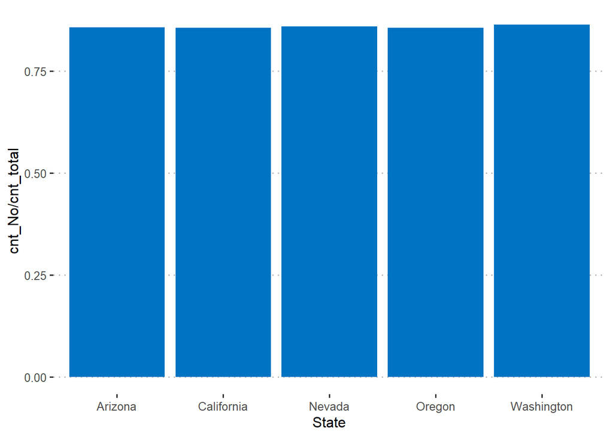

```r
plot_influence_factor_in_response("State")
```

Como vemos, claramente no existe un estado que muestre diferencias significativas en la respuesta, por lo que esta variable no ayuda mucho a la clasificación de manera individual.

## 1.2.1.2. Factor cobertura

```
##    Coverage cnt_No cnt_total
## 1:    Basic   4770      5568
## 2: Extended   2352      2742
## 3:  Premium    704       824
```

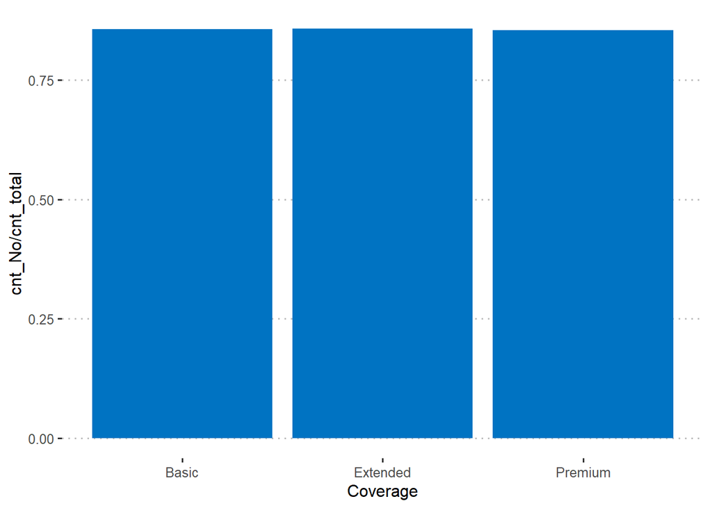

```r
plot_influence_factor_in_response("Coverage")
```

## 1.2.1.3. Factor educación

```
##               Education cnt_No cnt_total
## 1:             Bachelor   2370      2748
## 2:              College   2273      2681
## 3:               Doctor    282       342
## 4: High School or Below   2280      2622
## 5:               Master    621       741
```

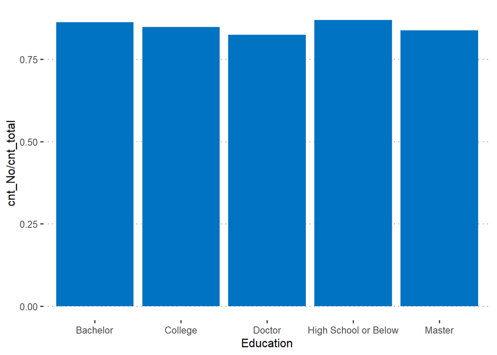

```r
plot_influence_factor_in_response("Education")
```

Vemos que en este caso, sí se presentan diferencias, pero mínimas.

## 1.2.1.4. Factor fecha

Introducimos una nueva variable en el dataset, con el fin de poder ver el impacto de la fecha a un nivel de detalle superior al del día.

```
##      month cnt_No cnt_total
## 1: 2011-01   4142      4898
## 2: 2011-02   3684      4236
```

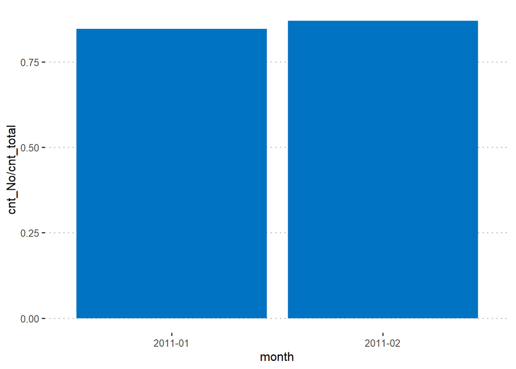

```r
market_data_dt$month <- format(as.Date(market_data_dt$Effective.To.Date, format="%m/%d/%y"), '%Y-%m')

plot_influence_factor_in_response("month")
```

Igualmente, representamos la información a nivel diario.

```
##     Effective.To.Date cnt_No cnt_total
##  1:            1/1/11    124       148
##  2:           1/10/11    159       195
##  3:           1/11/11    124       166
##  4:           1/12/11    108       126
##  5:           1/13/11    127       145
##  6:           1/14/11    122       152
##  7:           1/15/11    129       153
##  8:           1/16/11    130       142
##  9:           1/17/11    168       180
## 10:           1/18/11    136       154
## 11:           1/19/11    143       179
## 12:            1/2/11    136       160
## 13:           1/20/11    137       173
## 14:           1/21/11    130       160
```

[output cut: 46 more lines]

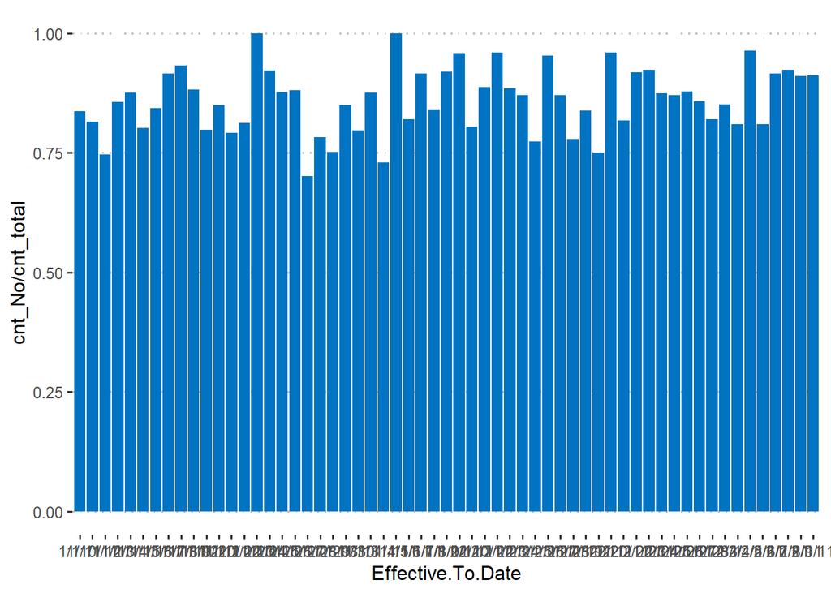

```r
plot_influence_factor_in_response("Effective.To.Date")
```

## 1.2.1.5. Factor empleado

```
##    EmploymentStatus cnt_No cnt_total
## 1:         Disabled    333       405
## 2:         Employed   4942      5698
## 3:    Medical Leave    354       432
## 4:          Retired     78       282
## 5:       Unemployed   2119      2317
```

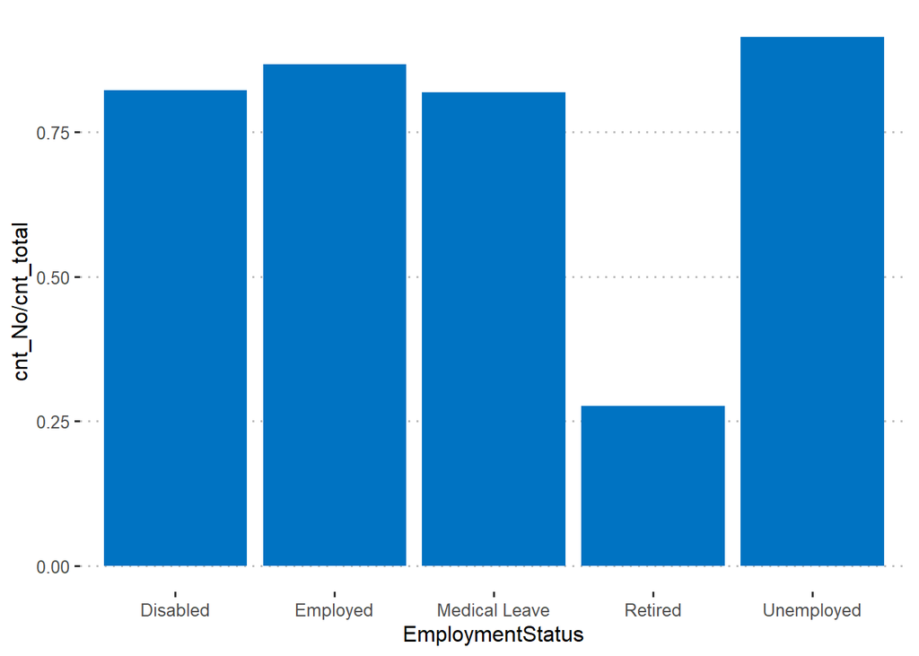

```r
plot_influence_factor_in_response("EmploymentStatus")
```

## 1.2.1.6. Factor género

```
##    Gender cnt_No cnt_total
## 1:      F   3998      4658
## 2:      M   3828      4476
```

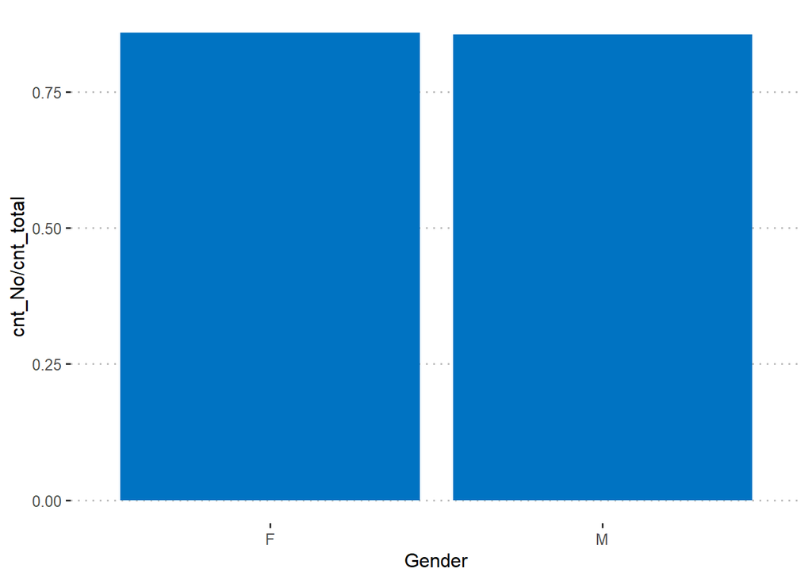

```r
plot_influence_factor_in_response("Gender")
```

EL factor genéro no discrimina en absoluto las clases.

## 1.2.1.7. Factor localización

```
##    Location.Code cnt_No cnt_total
## 1:         Rural   1611      1773
## 2:      Suburban   4771      5779
## 3:         Urban   1444      1582
```

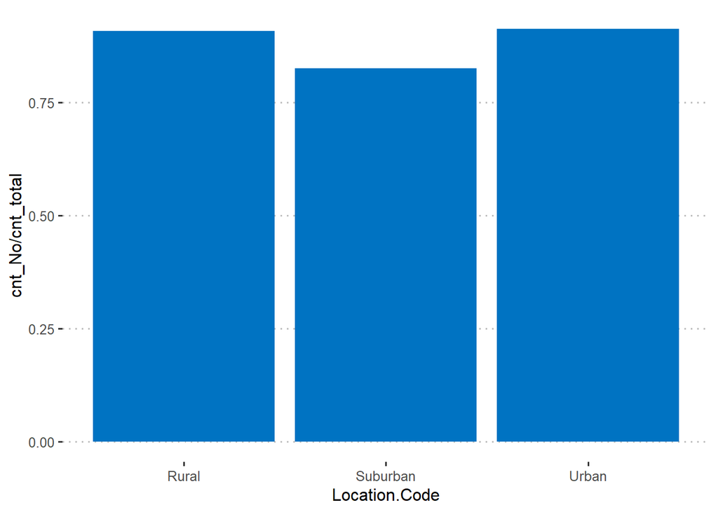

```r
plot_influence_factor_in_response("Location.Code")
```

## 1.2.1.8. Factor estado marital

```
##    Marital.Status cnt_No cnt_total
## 1:       Divorced   1045      1369
## 2:        Married   4602      5298
## 3:         Single   2179      2467
```

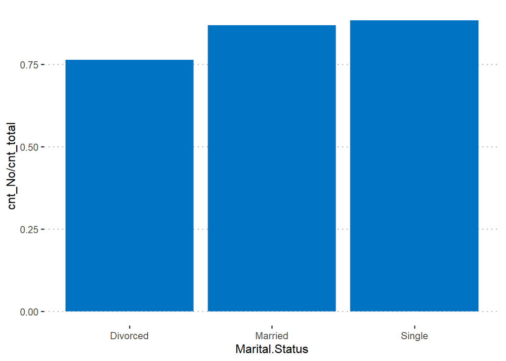

```r
plot_influence_factor_in_response("Marital.Status")
```

Como se ve en el gráfico, aprece que este factor sí que tiene cierto efecto, teniendo una mayor tendencia a la contratación aquéllos que están divorciados de los que no.

## 1.2.1.9. Factor tipo de póliza

```
##       Policy.Type cnt_No cnt_total
## 1: Corporate Auto   1680      1968
## 2:  Personal Auto   5830      6788
## 3:   Special Auto    316       378
```

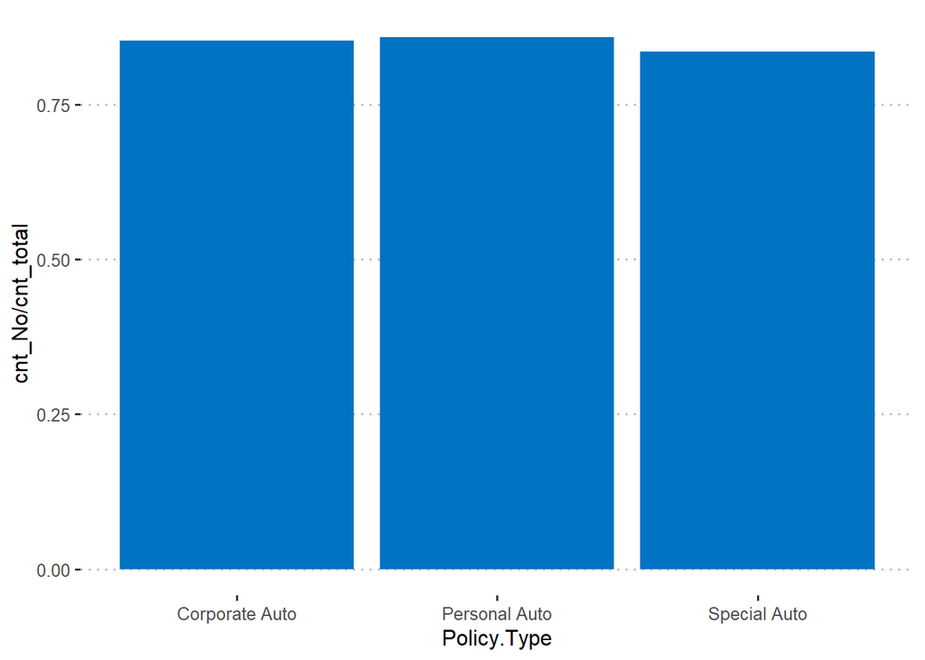

```r
plot_influence_factor_in_response("Policy.Type")
```

A tenor de los datos, no parece que este factor permita discriminar la variable respuesta.

## 1.2.1.10. Factor póliza

```
##          Policy cnt_No cnt_total
## 1: Corporate L1    311       359
## 2: Corporate L2    507       595
## 3: Corporate L3    862      1014
## 4:  Personal L1   1055      1240
## 5:  Personal L2   1817      2122
## 6:  Personal L3   2958      3426
## 7:   Special L1     54        66
## 8:   Special L2    145       164
## 9:   Special L3    117       148
```

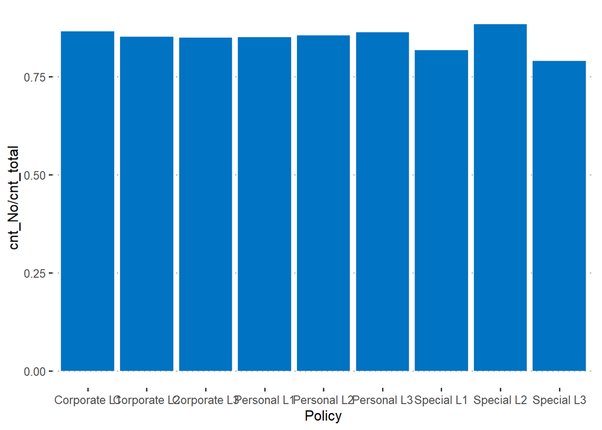

```r
plot_influence_factor_in_response("Policy")
```

Las pólizas especiales parecen tener un comportamiento distinto en cuando a la variabe respuesta.

## 1.2.1.11. Factor tipo oferta de renovación

```
##    Renew.Offer.Type cnt_No cnt_total
## 1:           Offer1   3158      3752
## 2:           Offer2   2242      2926
## 3:           Offer3   1402      1432
## 4:           Offer4   1024      1024
```

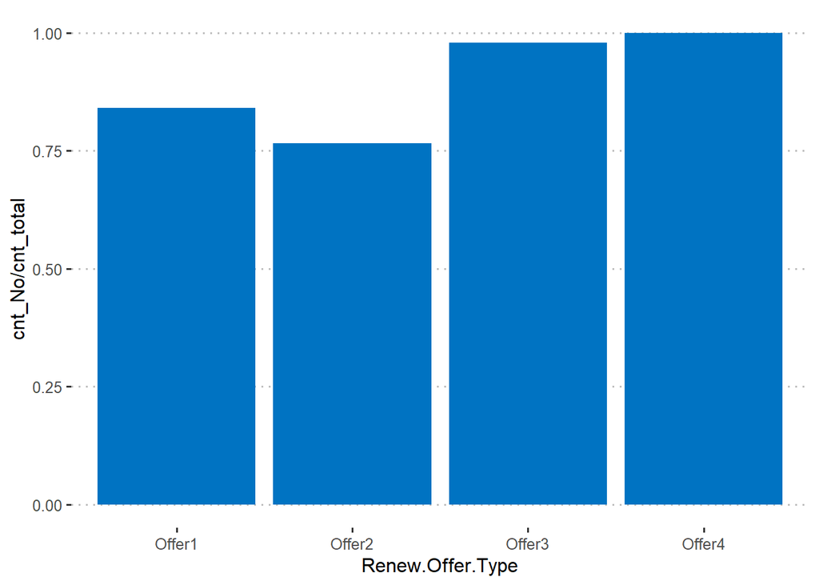

```r
plot_influence_factor_in_response("Renew.Offer.Type")
```

## 1.2.1.12. Factor canal venta

```
##    Sales.Channel cnt_No cnt_total
## 1:         Agent   2811      3477
## 2:        Branch   2273      2567
## 3:   Call Center   1573      1765
## 4:           Web   1169      1325
```

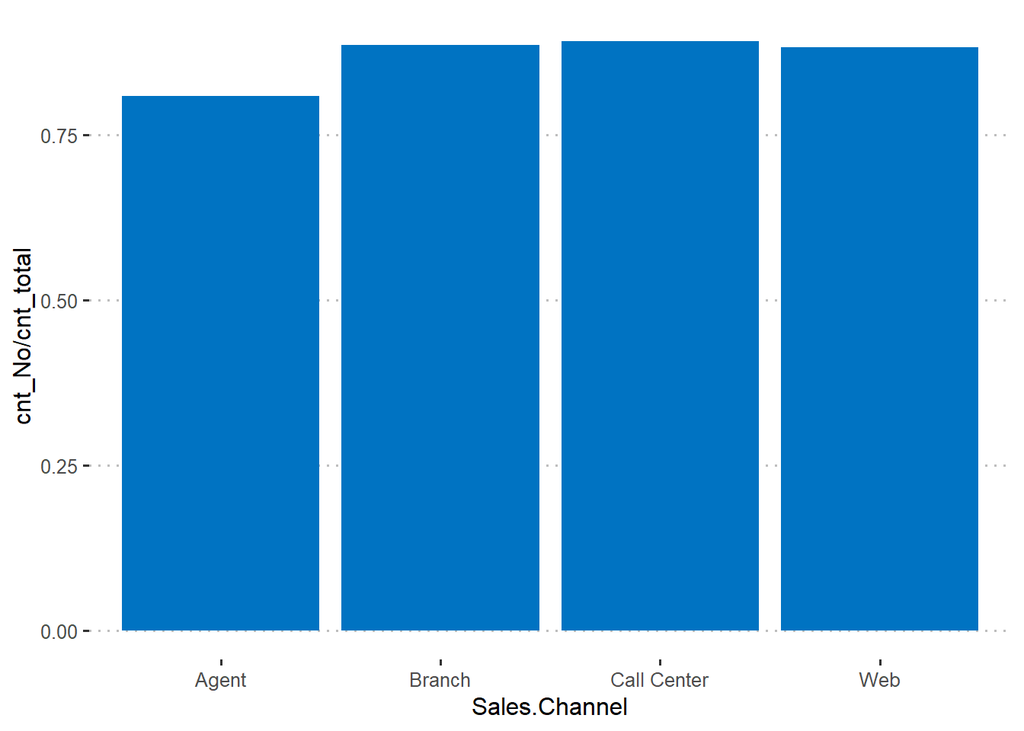

```r
plot_influence_factor_in_response("Sales.Channel")
```

El factor agente parece tener una mejor respuesta que los otros canales.

## 1.2.1.13. Factor clase vehículo

```
##    Vehicle.Class cnt_No cnt_total
## 1: Four-Door Car   3997      4621
## 2:    Luxury Car    151       163
## 3:    Luxury SUV    154       184
## 4:    Sports Car    394       484
## 5:           SUV   1508      1796
## 6:  Two-Door Car   1622      1886
```

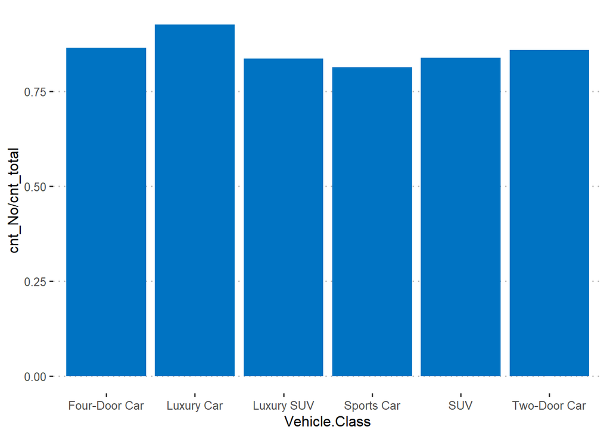

```r
plot_influence_factor_in_response("Vehicle.Class")
```

Este factor parece ser más significativo respecto a la discriminación de la variable respuesta.

## 1.2.1.14. Factor tamaño vehículo

```
##    Vehicle.Size cnt_No cnt_total
## 1:        Large    778       946
## 2:      Medsize   5482      6424
## 3:        Small   1566      1764
```

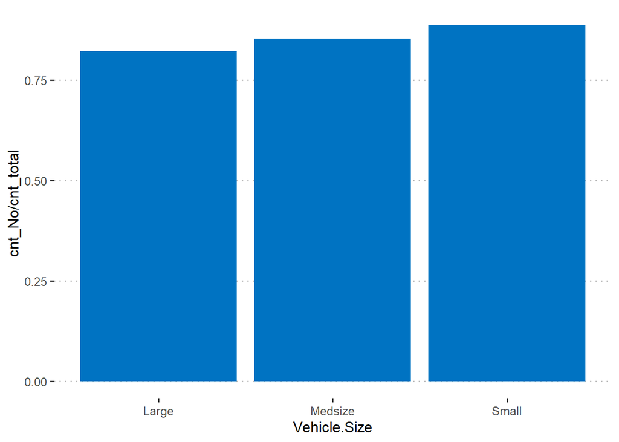

```r
plot_influence_factor_in_response("Vehicle.Size")
```

La aceptación suele ser más positiva cuanto más grande es el coche.

## 1.3. Primer análisis gráfico de la separabilidad

Realizamos igualmente un primer análisis básico a nivel gráfico, tomando algunos de las variables predictoras para ver si se observa una separación de las clases bajo algún par de variables.

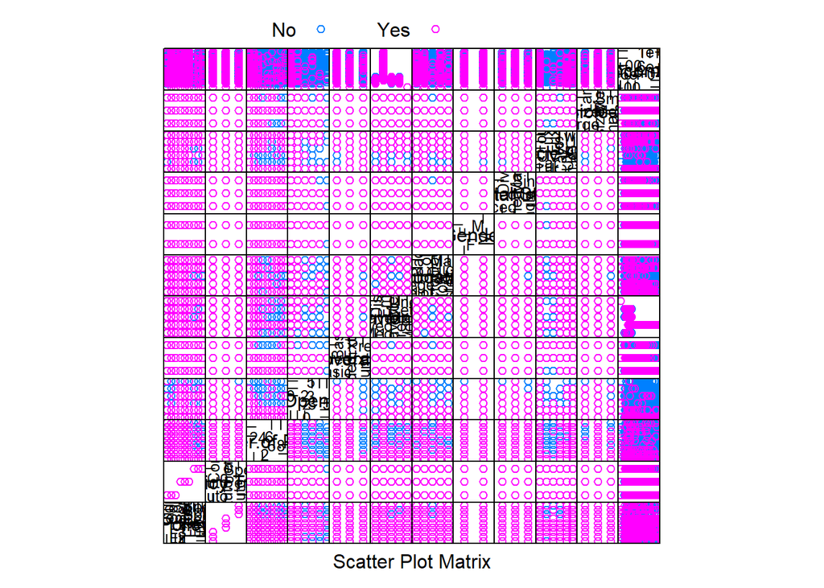

```r
featurePlot(x = market_data_dt[, .(Policy, Policy.Type, Number.of.Policies, Number.of.Open.Complaints,
                Coverage, EmploymentStatus, Education, Gender, Marital.Status,Vehicle.Class, Vehicle.Size,
                Income)],
              market_data_dt[, -3],
            y = market_data_dt$Response,
            plot = "pairs",
            auto.key = list(columns = 3))
```

A la vista de los resultados, no parece haber dos criterios que permitan separar las clases, al menos linealmente. Volveremos más adelante al análisis gráfico.

## 2. Preprocesado de datos

Aplicamos en este apartado las primeras fases del proprocesado de datos:

- Estudio e imputación de los valores faltantes
- Transformación de las variables continuas sesgadas y normalización de variables
- Estudio de valores atípicos
- Transformación de los factores mediante adición de variables dummy
- Segundo estudio gráfico mediante PCA y LDA de la separabilidad
- Estudio de la correlación de variables y primera reducción de la dimensionalidad
- Estudio de los predictores con variabilidad casi nula
- Aplicación del algoritmo boruta (wrapper) basado en random forest para selección de variables

## 2.1. Estudio e imputación de los valores faltantes

```r
n_valores_faltantes <- nrow(na.omit(market_data_dt, invert=TRUE))
total_valores <- nrow(market_data_dt)
n_valores_faltantes
```

```
## [1] 0
```

No existen datos faltantes, por lo que no hay que hacer nada en este apartado.

## 2.2. Transformación de las variables continuas sesgadas y normalización de variables

Existen varios motivos para tratar las variables que presentan una fuerte asimetría:

- Bajo la hipóstesis de normalidad (caso de perfecta simetría), los algoritmos suelen funcionar mejor
- Algunos algoritmos, como PCA o LDA, pueden verse perjudicados bajo la presencia de fuertes asimetrías
- Pueden dar lugar a confusión en la detección de valores atípicos

Por estas razones, vamos a abordar la transformación de aquéllas variables que presenten este problema, realizando igualmente la normalización de las variables:

```r
transformation <- preProcess(market_data_dt,method = c("BoxCox", "center", "scale"))
normalized_data <- predict(transformation, market_data_dt)
```

Eliminamos la variable auxiliar que habíamos usado para la exploración de los datos Response_n y la variable Customer que no tiene ningúin papel en el análisis. Además, sustituímos la variable Effective.To.Date a nivel diiario por la variable month que resume la información en dos niveles.

```r
normalized_data[, Response_n:=NULL]
normalized_data[, Customer:=NULL]
normalized_data[, Effective.To.Date:=NULL]
```

## 2.3. Estudio de los valores atípicos

Haremos un análisis unidimensional de los valores atípicos sobre las variables numéricas del dataset. La siguiente función, dado un data table y un conjunto de columnas del dataset, las recorre mostrando el diagrama de caja bigote y el número de valores atípicos.

```
## [1] "Diagrama de caja bogotes para variable Income"
```

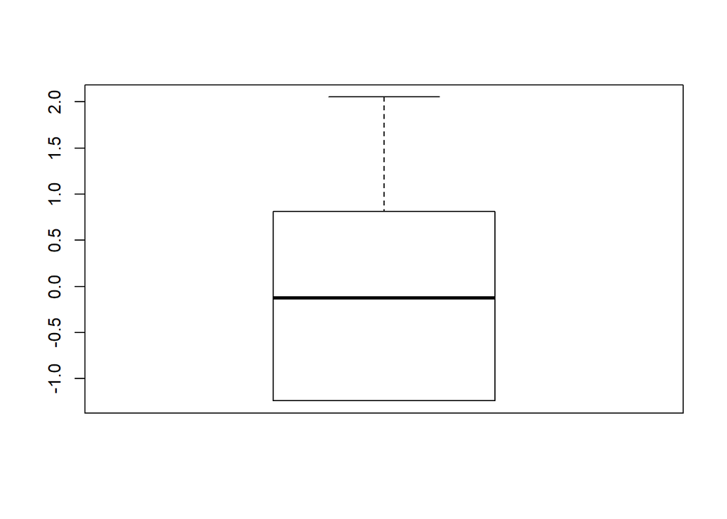

```
## [1] "Número de valores atípicos 0"
## [1] "Diagrama de caja bogotes para variable Customer.Lifetime.Value"
```

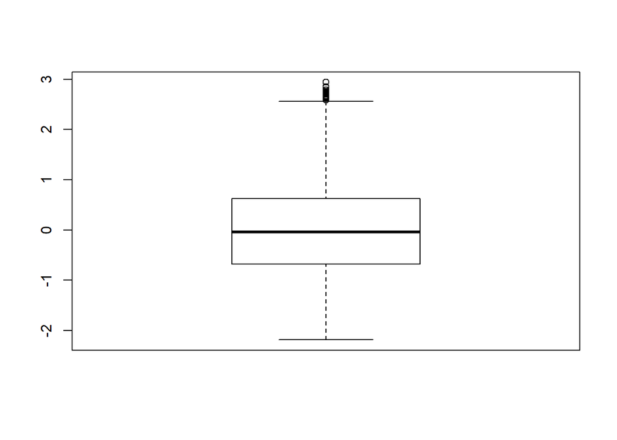

```
## [1] "Número de valores atípicos 16"
## [1] "Diagrama de caja bogotes para variable Monthly.Premium.Auto"
```

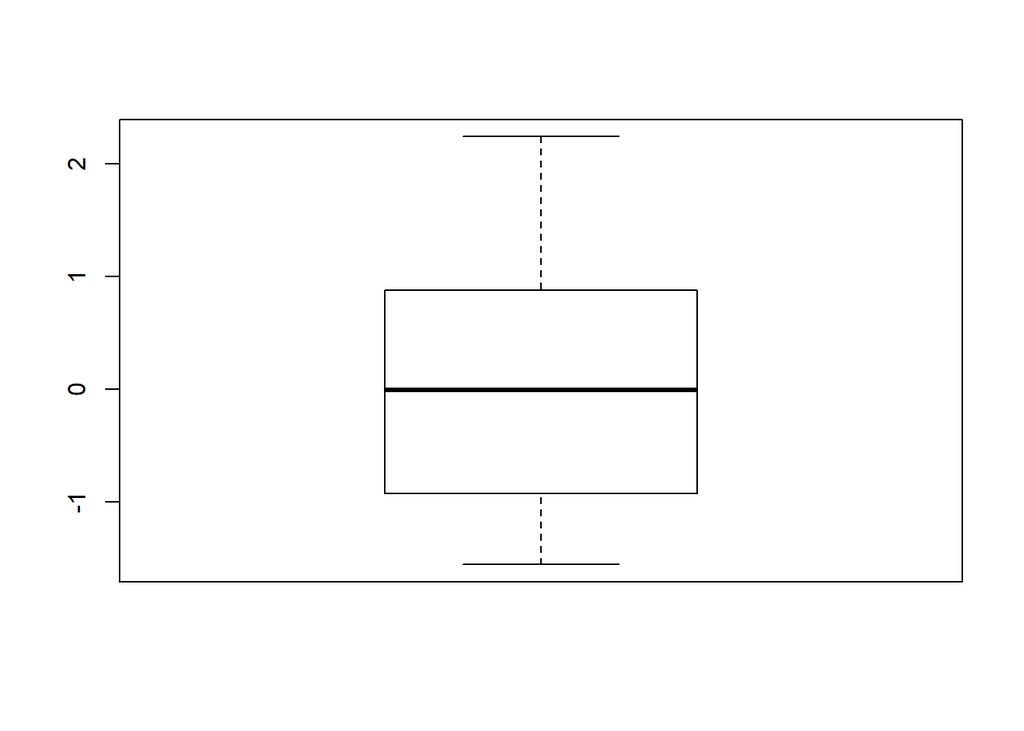

```
## [1] "Número de valores atípicos 0"
## [1] "Diagrama de caja bogotes para variable Months.Since.Last.Claim"
```

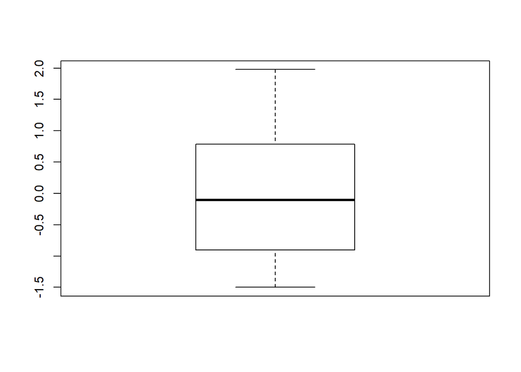

```
## [1] "Número de valores atípicos 0"
## [1] "Diagrama de caja bogotes para variable Months.Since.Policy.Inception"
```

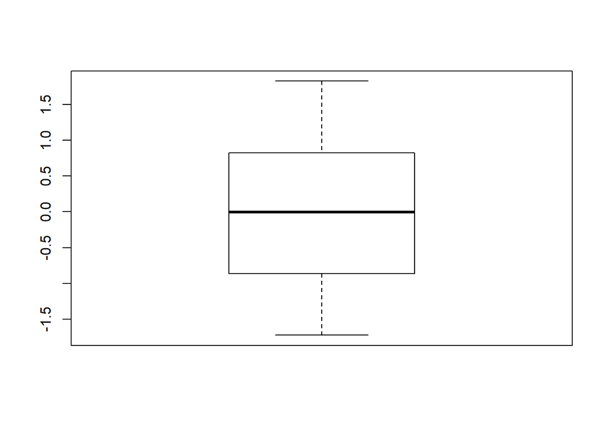

```
## [1] "Número de valores atípicos 0"
## [1] "Diagrama de caja bogotes para variable Number.of.Open.Complaints"
```

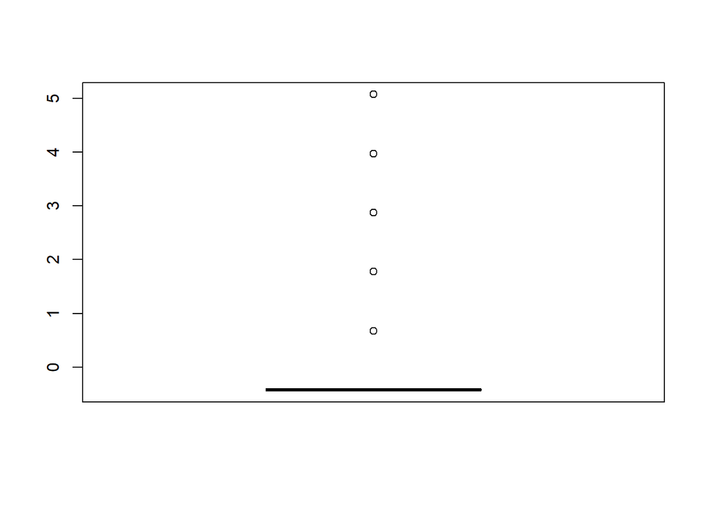

```
## [1] "Número de valores atípicos 1882"
## [1] "Diagrama de caja bogotes para variable Total.Claim.Amount"
```

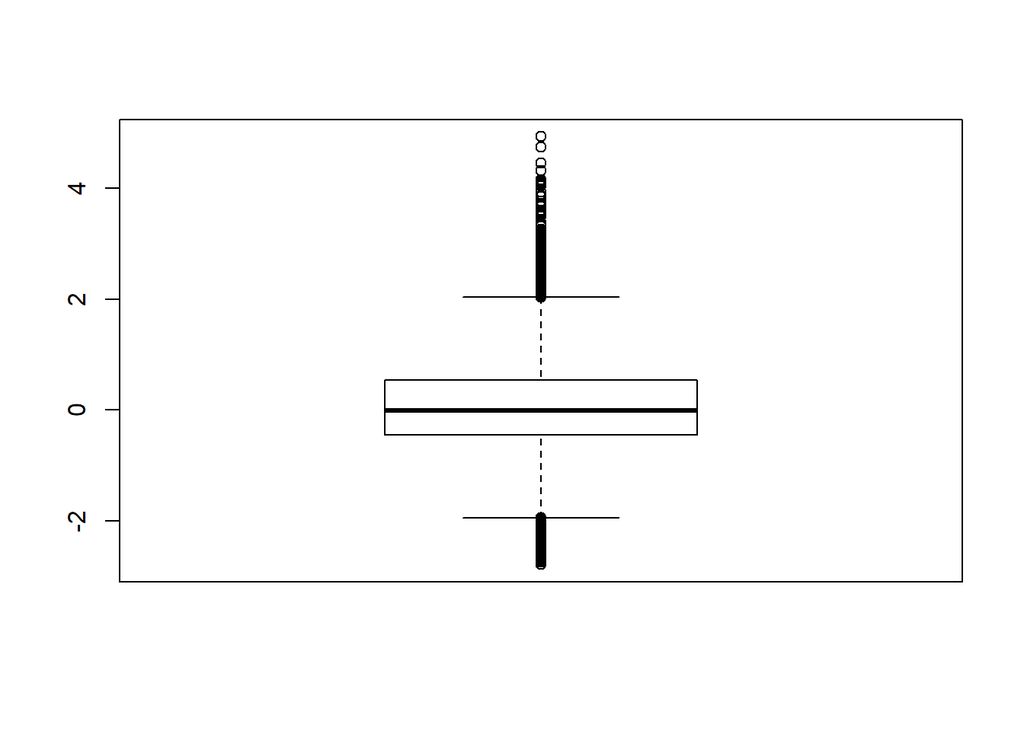

```
## [1] "Número de valores atípicos 563"
```

```r
show_outlier <- function(dt, var_vector) {
  #temp <- quote(Income)
  for(var in var_vector) {
    data <- dt[, eval(var)]
    print(paste("Diagrama de caja bogotes para variable", var))
    boxplot(data)
    print(paste("Número de valores atípicos", length(boxplot.stats(data)$out)))
  }
}

show_outlier(normalized_data, c(quote(Income),
                                quote(Customer.Lifetime.Value),
                                quote(Monthly.Premium.Auto),
                                quote(Months.Since.Last.Claim),
                                quote(Months.Since.Policy.Inception),
                                quote(Number.of.Open.Complaints),
                                quote(Total.Claim.Amount)
                               )
             )
```

Se presentan valores atípicos en tres variables:

- Number.of.Open.Complaints
- Total.Claim.Amount
- Customer.Lifetime.Value

En algunos casos, los valores atípicos pueden venir de errores (por ejemplo, una mala calibración en un sensor o datos erróneos introducios manualmente). En otras, como parece en este caso, responden a casuísticas de negocio. Valores atípicamente altos en en tiempo de vida del cliente, o que presenten un número muy elevado sobre la media que quejas o cantidades requeridas a la compañía atípicamente bajas o altas respecto del nivel medio son escenarios perfectamente válidos de negocio. Por lo tanto, no vamos a eliminar estos valores atípicos en este caso particular, ya que no parecen responder a un error en los datos.

## 2.4. Transformación de los factores mediante adición de variables dummy

Con el objetivo de poder manipular los factores a nivel analítico, introducimos variables dummy o indicadores. La transformación consiste en añadir una variable por cada factor y nivel, teniendo un indicador de cuál es el nivel al que pertenece. De esta manera, podemos aplicar los métodos analíticos (como PCA, análisis de correlaciones, etc).

```r
transformed_dt <- dummy.data.frame(normalized_data[, -3])

transformed_dt$Response <- normalized_data$Response
```

## 2.5. Segundo estudio gráfico y mediante LDA de la separabilidad

Tras la transformación de las variables factoriales en numéricas, vamos a estudiar de nuevo gráficamente la separabilidad del conjunto, realizando previamente una transformación lineal de las variables originales (PCA, LDA). De esta forma, podremos tener una primera idea intuitiva más clara de si el conjunto es o no linealmente separable y, por lo tanto, qué tipo de técnicas son más adecuadas tanto para la selección de características como la elección de los algoritmos a entrenar.

## 2.5.1. Estudio gráfico de la separabilidad mediante análisis de componentes principales

El método PCA consiste en la transformación de las variables originales en una nuevas variables incorreladas, mediante una transformación ortonormal que permite conservar la varianza de las variables originales. Por lo tanto, a priori no tienen por qué conservar la separabilidad del dataset. Sin embargo, a nivel exploratorio, sí que puede ser interesante realizar el estudio gráfico sobre las primeras componentes principales, las que llevan el mayor peso de la varianza, pues pueden dar una idea del patrón que hay subyacente a los datos.

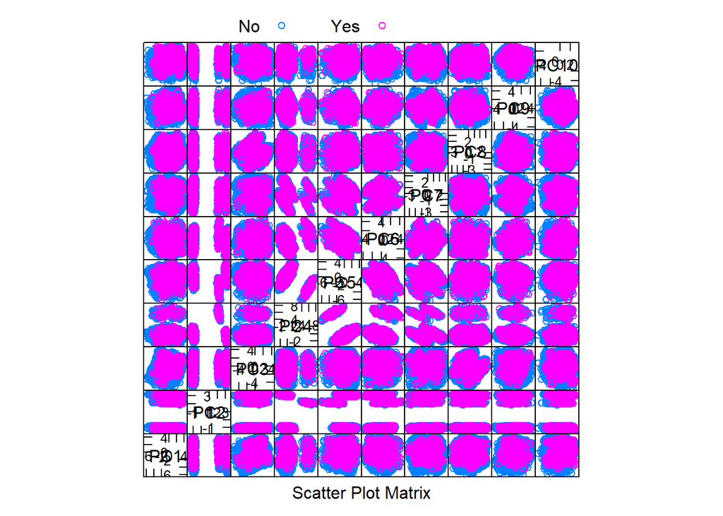

```r
pca <- prcomp(transformed_dt[, names(transformed_dt) != "Response"], scale = TRUE)

scores <- as.data.table(predict(pca))
scores$response <- transformed_dt$Response

featurePlot(x = scores[, .(PC1, PC2, PC3, PC4, PC5, PC6, PC7, PC8,PC9, PC10)],
            y = scores$response,
            plot = "pairs",
            auto.key = list(columns = 3))
```

Observamos un fenómeno similar al que obtuvimos al realizar el primer análisis gráfico, no siendo posible obtener una proyección que nos permita separar los datos.

## 2.5.2. Estudio de la separabildiad mediante LDA

La idea que hay detrás del método LDA (Linear Discriminant analisys) es buscar un espacio de dimensión menor (particularmente un hiperplano), que maximize la varianza entre grupos y minimice la varianza intra grupos. Es decir, se busca un hiperplano donde la separación entre las variables sea lo mayor posible, mediante una aplicación lineal (una proyección concretamente). A diferencia del PCA, este método sí conserva, si el dataset es linealmente separable, la separabilidad entre las clases.

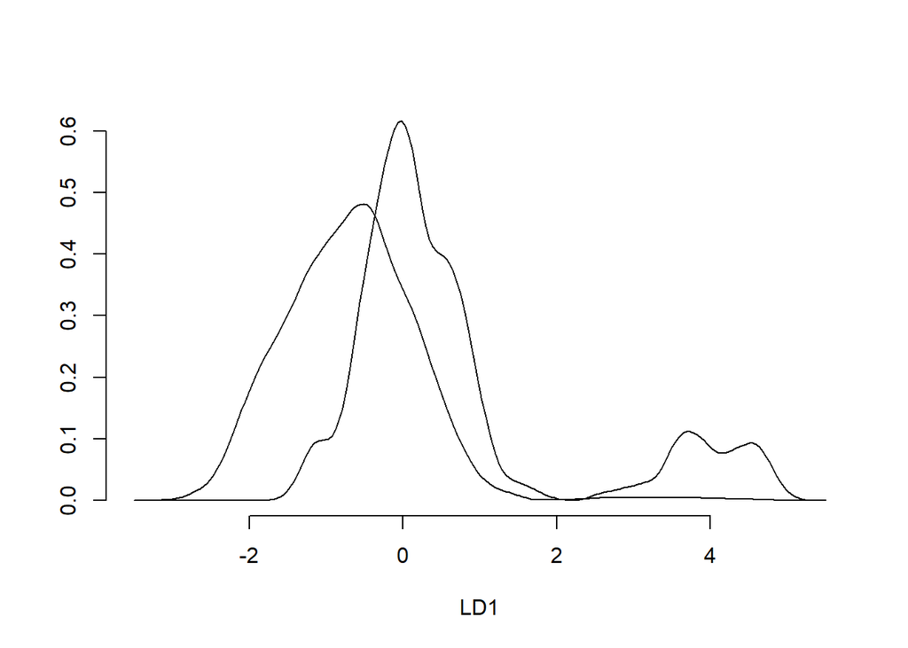

```r
lda <- lda(Response ~ .,
           data=transformed_dt)

plot(lda, panel = panel.lda, cex = 0.7, dimen = 1, abbrev = FALSE, type ="density")
```

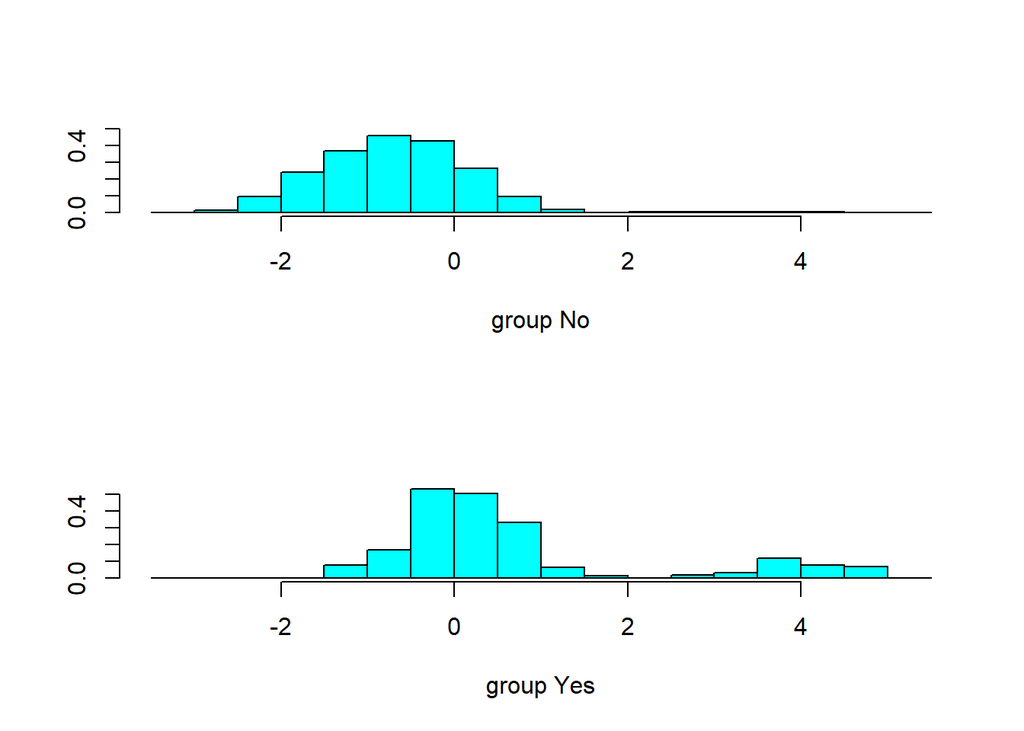

```r
plot(lda, panel = panel.lda, cex = 0.7, dimen = 1, abbrev = FALSE, type ="histogram")
```

Vemos, sin embargo, que las clases están muy contaminadas. Por tanto, no es una buena idea, con vistas a la selección de variables, emplear ninguno de los métodos lineales (PCA, LDA, o PLDSA).

## 2.6. Estudio de la correlación de variables y primera reducción de la dimensionalidad

Estudiamos gráficamente la correlación entre las variables, clusterizando aquéllos grupos de variables que guarden una alta correlación entre sí (con la opción ‘hclust’). Igualmente, mediante el algoritmo findcorrelation, seleccionamos aquéllas variables que tengan una correlación superior a 0.9 (prácticamente el caso en que las variables son coliniales y que, por lo tanto, muestra una clara redundancia). Para cada par de variables con correlación superior a la especificada en el parámetro, el algoritmo selecciona la que tenga una mayor correlación media con el resto de variables.

Matriz de correlaciones clusterizada:

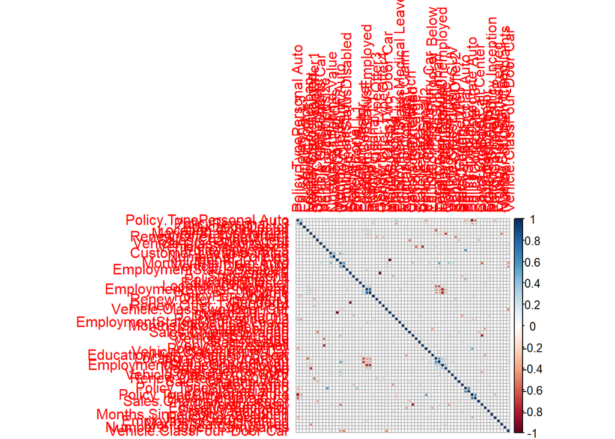

```r
correlations <- cor(transformed_dt[, names(transformed_dt) != "Response"])
corrplot(correlations, order = "hclust")
```

Variables seleccionadas por el algoritmo:

```r
highCorr <- findCorrelation(correlations, cutoff = .90)
colnames(transformed_dt[highCorr])
```

```
## [1] "GenderM"      "month2011-02"
```

```r
#transformed_dt <- transformed_dt[-highCorr]
```

De momento, no eliminamos las variables.

## 2.7. Estudio de los predictores con variabilidad casi nula

Estudiamos la existencia de variables con varianza (casi) nula. Se entiende por éstas las variables en las que:

- Existe un gran ratio entre el mayor valor y el segundo mayor valor
- Tienen un único valor no nulo y el porcentaje del valor no nulo es muy pequeño respecto al tamaño de muestra

Es conveniente detectar y tratar este tipo de variables, ya que pueden afectar negativamente a los algoritmos de predicción. Listamos a continuación las variables (casi) nulas para el dataset.

```r
colnames(transformed_dt[, nearZeroVar(transformed_dt)])
```

```
##  [1] "EducationDoctor"               "EmploymentStatusDisabled"
##  [3] "EmploymentStatusMedical Leave" "EmploymentStatusRetired"
##  [5] "Policy.TypeSpecial Auto"       "PolicyCorporate L1"
##  [7] "PolicySpecial L1"              "PolicySpecial L2"
##  [9] "PolicySpecial L3"              "Vehicle.ClassLuxury Car"
## [11] "Vehicle.ClassLuxury SUV"
```

En todos estos casos, se nos muestran aquéllos factores que tienen muy poca cantidad de datos con respecto al total de la muestra. Pero, como hemos visto en la fase de preprocesado, muchas de estas características discriman la variable respuesta (aunque muy débilmente) y, por lo tanto, no es buena idea eliminarlas en una primera instancia.

# 2.8. Aplicación del algoritmo boruta para reducción de la dimensionaldiad y selección de variables

Como hemos visto en el análisis gráfico, los algoritmos de selección de variables lineales tales como PCA, LDA, PLDSA, etc no son convenientes para seleccionar las variables predictivas del modelo. Por tanto, hemos optado por tomar uno de la familia wrapper, el método boruta, el cual está basado en el algoritmo de clasificación random forest. Los pasos que sigue el algoritmo son los siguientes:

```
 - Para cada variable, se crea una variable espejo obtenida a partir de la original reordenando arbitrariamente los valores de las variables. De esta forma, se pretenden conseguir variables con la mínima relación posible con la variable respuesta.
 - Se ejecuta el random forest incluyendo las variables espejo y se toman las puntuaciones Z (se definen como la distancia, tomando como unidad de medida la varianza de la variable, con respecto a la media)
 - Tomar la variable con mayor valor espejo y asignar un punto (hit) a aquéllas variables que tenga una puntuación mayor que ésta
 - Repetir los pasos anterior un número n de iteraciones
```

El algoritmo realiza un test en el casos en los que no pueda aplicar el criterio mencionado en el tercer punto, aunque no aplica en este caso particular y, por lo tanto, no describimos dichos pasos. La idea principal es la definición, mediante la creación de la variables espejo, de un criterio para determinar si una variable es importante. Áquellas variables que tengan una puntuación menor que las variables espejo, demuestran no ser importantes en la predicción de la variable respuesta, ya que tienen menos relación con la variable respuesta que variables generadas aleatoriamente y, por lo tanto, se pueden descartar. Así el algoritmo no sólo es capaz de eliminar las variables superfluas sino que también es capaz de cuantificar el peso que tienen en la predicción.

Ejecutamos el algoritmo boruta:

```r
set.seed(123)
#boruta_feature_selection <- Boruta(x = trasnformed_dt[, names(trasnformed_dt) != "Response"], y = trasnformed_dt$Response, doTrace = 2)

#saveRDS(boruta_feature_selection, file = "boruta_fs.rds")
boruta_feature_selection <-  readRDS(file = "boruta_fs.rds")
```

Gráfico con la importancia de las variables:

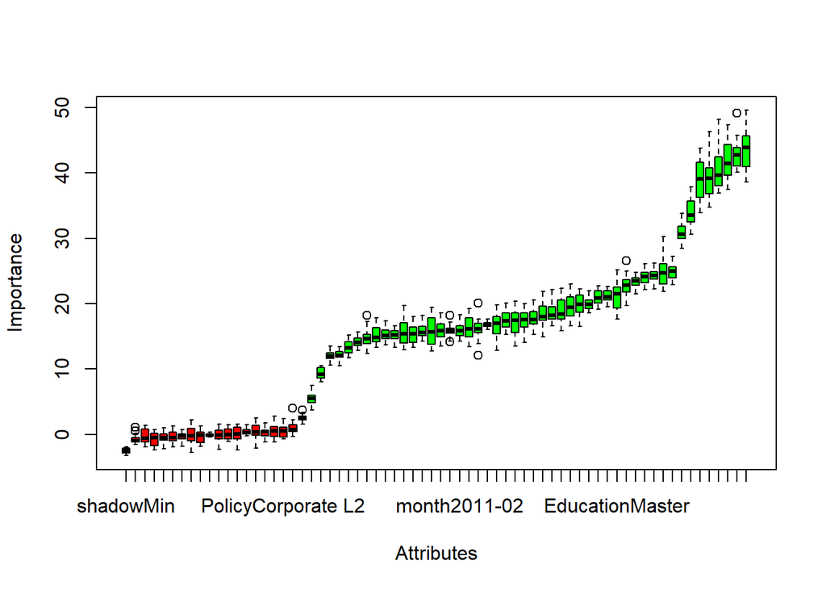

```r
plot(boruta_feature_selection)
```

```r
s_attr <- getSelectedAttributes(boruta_feature_selection)
select_attr_ds <- transformed_dt[, s_attr]
select_attr_ds$Response <- transformed_dt$Response
```

Variables seleccionadas:

```r
dim(select_attr_ds)
```

```
## [1] 9134   49
```

```r
colnames(select_attr_ds)
```

```
##  [1] "Customer.Lifetime.Value"       "CoverageBasic"
##  [3] "CoverageExtended"              "CoveragePremium"
##  [5] "EducationBachelor"             "EducationCollege"
##  [7] "EducationDoctor"               "EducationHigh School or Below"
##  [9] "EducationMaster"               "EmploymentStatusDisabled"
## [11] "EmploymentStatusEmployed"      "EmploymentStatusMedical Leave"
## [13] "EmploymentStatusRetired"       "EmploymentStatusUnemployed"
## [15] "GenderF"                       "GenderM"
## [17] "Income"                        "Location.CodeRural"
## [19] "Location.CodeSuburban"         "Location.CodeUrban"
## [21] "Marital.StatusDivorced"        "Marital.StatusMarried"
## [23] "Marital.StatusSingle"          "Monthly.Premium.Auto"
## [25] "Months.Since.Last.Claim"       "Months.Since.Policy.Inception"
## [27] "Number.of.Open.Complaints"     "Number.of.Policies"
## [29] "Renew.Offer.TypeOffer1"        "Renew.Offer.TypeOffer2"
## [31] "Renew.Offer.TypeOffer3"        "Renew.Offer.TypeOffer4"
## [33] "Sales.ChannelAgent"            "Sales.ChannelBranch"
## [35] "Sales.ChannelCall Center"      "Sales.ChannelWeb"
## [37] "Total.Claim.Amount"            "Vehicle.ClassFour-Door Car"
## [39] "Vehicle.ClassLuxury Car"       "Vehicle.ClassLuxury SUV"
## [41] "Vehicle.ClassSports Car"       "Vehicle.ClassSUV"
## [43] "Vehicle.ClassTwo-Door Car"     "Vehicle.SizeLarge"
## [45] "Vehicle.SizeMedsize"           "Vehicle.SizeSmall"
## [47] "month2011-01"                  "month2011-02"
## [49] "Response"
```

# 3. Equilibrado de la muestra

Finalmente, equilibramos la muestra mediante el método del cubo:

```r
datos_no <- subset(select_attr_ds, select_attr_ds$Response == "No")
datos_si <- subset(select_attr_ds, select_attr_ds$Response == "Yes")

nA <- nrow(datos_no)
nB <- nrow(datos_si)

UNO=rep(1,dim(datos_no)[1])

pik = rep(nB/nA, nA)

X <- cbind(UNO, dim(datos_no[, names(datos_no) != "Response"])[1])


s=samplecube(as.matrix(X), pik, method=2)
```

```
##
## BEGINNING OF THE FLIGHT PHASE
## The matrix of balanced variable has 2  variables and  7826  units
## The size of the inclusion probability vector is  7826
## The sum of the inclusion probability vector is  1308
## The inclusion probability vector has  7826  non-integer elements
## Step 1  Step  2 ,
##
##
## QUALITY OF BALANCING
##       TOTALS HorvitzThompson_estimators Relative_deviation
## UNO     7826                       7826       1.092416e-12
## 2   61246276                   61246276       1.666599e-12
```

```r
muestra = cbind(datos_no,s)
muestra1 <- muestra[muestra$s == 1,]
muestra1$s  <- NULL
datos_balanceados <- rbind(muestra1,datos_si)


#write.csv2(datos_balanceados, file="C:/Users/ricar/OneDrive/Escritorio/datos_blanceados.csv")
```

# 4 Entrenamiento de los algoritmos

Usaremos las siguientes funciones a lo largo del presente apartado, las cuales resumen la información de los modelos y calculan la curva ROC y la matriz de confución, tanto para los datos de entrenamiento como de test. Además, particionamos los datos devueltos por el método del cubo en datos de muestra y validación.

```r
set.seed(123)
train.index <- caret::createDataPartition(y = datos_balanceados$Response, p= 0.8, list = FALSE)
data.training <- datos_balanceados[train.index,]
data.testing <- datos_balanceados[-train.index,]



get_model_results <- function(model, plot_param, show_confusionMatrix) {
  print(paste("Resultados para cada uno de los parámetros de la malla:"))
  print(model)
  print(paste("#######################################################"))
  print(paste("Matriz de confusión del modelo:"))
  print(paste("#######################################################"))
  print(confusionMatrix(model))
  if(show_confusionMatrix) {
    print(paste("#######################################################"))
    print(paste("Matriz de confusión comparando las predicciones del modelo y los datos de test:"))
    print(paste("#######################################################"))
    print(confusionMatrix(predict(model, newdata = data.testing), data.testing$Response))
  }
  print(paste("#######################################################"))
  print(paste("Importancia de las variables:"))
  print(varImp(model))
  if(plot_param) {
    print(paste("Gráfico ROC-parámetros:"))
    plot(model)
  }
}


plot_roc_curve <- function(model) {
  print("Cruva ROC:")
  pred_prob_val <- predict(model, data.testing, type="prob")
  pred_prob_ent <- predict(model, data.training, type="prob")


  curvaROC_val <- roc(data.testing$Response,pred_prob_val[,"Yes"])
  curvaROC_ent <- roc(data.training$Response,pred_prob_ent[,"Yes"])

  plot(curvaROC_ent,col="blue", main="Simulación con la curva ROC del modelo")
  plot(curvaROC_val, col="red", add=TRUE)
  legend("bottomright", legend = c("Entrenamiento", "Validacion"), col = c("blue", "red"), lwd = 2)
}
```

Dado que el tamaño de muestra es pequeño (unos 2000 registros), usaremos tamaños para la malla no excesivamente grandes para evitar el sobreajuste. Igualmente, comparamos los datos obtenidos contrastando los datos de entrenamiento y validación.

# 4.1. C5.0

```r
#set.seed(123)
#fiveStats = function(...) c (twoClassSummary(...), defaultSummary(...))
#c5Grid <-  expand.grid(trials = 1:20,
#                        model = c("tree", "rules"),
#                        winnow = c(TRUE, FALSE))
#train.control <- trainControl(method = "repeatedcv", number = 10, repeats = 5, classProbs = TRUE, summaryFunction = #fiveStats)
#clusterCPU <- registerDoParallel(cores=detectCores() - 1)
#c5_0.fit <- train(Response ~ . ,
#             data = data.training,
#             method = "C5.0",
#             parms = list(split = "information"),
#             preProc = c("center", "scale"),
#             trControl = train.control,
#             metric = "ROC",
#              tuneGrid = c5Grid
#            )
#stopImplicitCluster()

#saveRDS(c5_0.fit, file = "c5_0.rds")
c5_0.fit <- readRDS(file = "c5_0.rds")
get_model_results(c5_0.fit, TRUE, TRUE)
```

```
## [1] "Resultados para cada uno de los parámetros de la malla:"
## C5.0
##
## 2094 samples
##   48 predictor
##    2 classes: 'No', 'Yes'
##
## Pre-processing: centered (48), scaled (48)
## Resampling: Cross-Validated (10 fold, repeated 5 times)
## Summary of sample sizes: 1884, 1885, 1884, 1885, 1885, 1885, ...
## Resampling results across tuning parameters:
##
##   model  winnow  trials  ROC        Sens       Spec       Accuracy
##   rules  FALSE    1      0.9178858  0.8414615  0.9847125  0.9130846
##   rules  FALSE    2      0.9418341  0.8993590  0.8718132  0.8855963
##   rules  FALSE    3      0.9641046  0.8586795  0.9904542  0.9245543
##   rules  FALSE    4      0.9758899  0.8688242  0.9862509  0.9275199
##   rules  FALSE    5      0.9831058  0.8875147  0.9978993  0.9426947
##   rules  FALSE    6      0.9889845  0.9196190  0.9969414  0.9582660
##   rules  FALSE    7      0.9910992  0.9131337  0.9984762  0.9557898
##   rules  FALSE    8      0.9929508  0.9354634  0.9988571  0.9671496
##   rules  FALSE    9      0.9939059  0.9333590  0.9992381  0.9662911
##   rules  FALSE   10      0.9949780  0.9434597  0.9994286  0.9714408
##   rules  FALSE   11      0.9955197  0.9465348  0.9994286  0.9729710
##   rules  FALSE   12      0.9961256  0.9484322  0.9994286  0.9739233
##   rules  FALSE   13      0.9961808  0.9528407  0.9994286  0.9761207
##   rules  FALSE   14      0.9964274  0.9545549  0.9994286  0.9769819
##   rules  FALSE   15      0.9969994  0.9587509  0.9990476  0.9788917
##   rules  FALSE   16      0.9972328  0.9600842  0.9994286  0.9797493
##   rules  FALSE   17      0.9975104  0.9637234  0.9994286  0.9815693
##   rules  FALSE   18      0.9973102  0.9654432  0.9994286  0.9824269
##   rules  FALSE   19      0.9973413  0.9642985  0.9990476  0.9816659
##   rules  FALSE   20      0.9974591  0.9694634  0.9994286  0.9844379
##   rules   TRUE    1      0.9243290  0.8473901  0.9860366  0.9167073
##   rules   TRUE    2      0.9438878  0.9098462  0.8741007  0.8919782
##   rules   TRUE    3      0.9629980  0.8626612  0.9891355  0.9258922
##   rules   TRUE    4      0.9758909  0.8830897  0.9868223  0.9349589
##   rules   TRUE    5      0.9840474  0.8878663  0.9969396  0.9423980
##   rules   TRUE    6      0.9886921  0.9182619  0.9965604  0.9574070
##   rules   TRUE    7      0.9914261  0.9148059  0.9992381  0.9570160
```

[output cut: 195 more lines]

```
## Renew.Offer.TypeOffer3          98.81
## Total.Claim.Amount              98.66
## Monthly.Premium.Auto            98.62
## Customer.Lifetime.Value         98.23
## Marital.StatusDivorced          94.99
## Location.CodeSuburban           93.70
## Number.of.Policies              93.17
## EducationDoctor                 92.98
## Vehicle.ClassSportsCar          92.60
## Renew.Offer.TypeOffer1          90.78
## EducationBachelor               89.83
## EducationMaster                 89.64
## Marital.StatusMarried           89.49
## Income                          87.30
## [1] "Gráfico ROC-parámetros:"
```

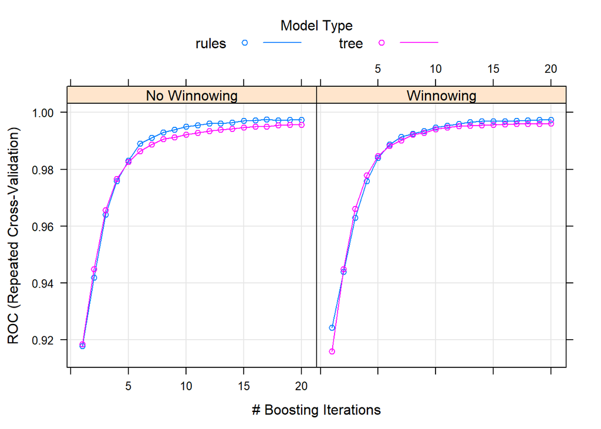

```
## [1] "Cruva ROC:"
```

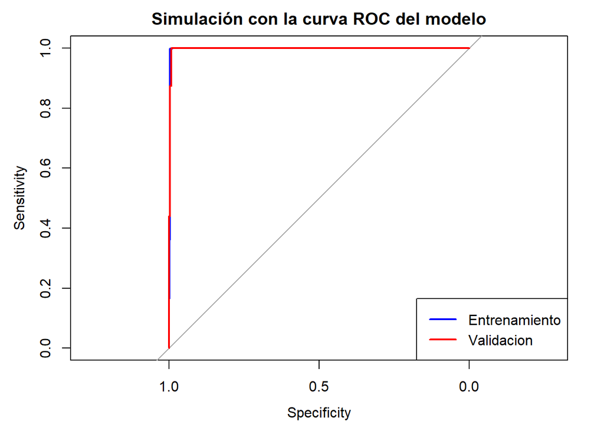

```r
plot_roc_curve(c5_0.fit)
```

# 4.2. Random Forest

```r
#set.seed(123)
#fiveStats = function(...) c (twoClassSummary(...), defaultSummary(...))
#RFGrid <-  expand.grid(mtry  = 1:15)
#train.control <- trainControl(method = "repeatedcv", number = 10, repeats = 5, classProbs = TRUE, summaryFunction = #fiveStats)
#clusterCPU <- registerDoParallel(cores=detectCores() - 1)
#rf.fit <- train(x = data.training[, names(data.training) != "Response"],
#             y = data.training$Response,
#             method = "parRF",
#             parms = list(split = "information"),
#             preProc = c("center", "scale"),
#             trControl = train.control,
#             metric = "ROC",
#              tuneGrid = RFGrid
#             )
#stopImplicitCluster()

#saveRDS(rf.fit, file = "rf.rds")
rf.fit <- readRDS(file = "rf.rds")
get_model_results(rf.fit, TRUE, TRUE)
```

```
## [1] "Resultados para cada uno de los parámetros de la malla:"
## Parallel Random Forest
##
## 2094 samples
##   48 predictor
##    2 classes: 'No', 'Yes'
##
## Pre-processing: centered (48), scaled (48)
## Resampling: Cross-Validated (10 fold, repeated 5 times)
## Summary of sample sizes: 1884, 1885, 1884, 1885, 1885, 1885, ...
## Resampling results across tuning parameters:
##
##   mtry  ROC        Sens       Spec       Accuracy   Kappa
##    1    0.9328261  0.7126282  0.9503168  0.8315159  0.6629904
##    2    0.9962404  0.8792381  0.9938956  0.9365684  0.8731352
##    3    0.9995372  0.9369542  0.9984762  0.9677109  0.9354222
##    4    0.9997780  0.9545403  0.9994286  0.9769773  0.9539554
##    5    0.9997998  0.9587308  0.9994286  0.9790758  0.9581517
##    6    0.9998015  0.9583590  0.9994286  0.9788885  0.9577773
##    7    0.9997916  0.9581685  0.9994286  0.9787928  0.9575862
##    8    0.9997321  0.9554945  0.9994286  0.9774549  0.9549108
##    9    0.9997202  0.9541557  0.9994286  0.9767846  0.9535700
##   10    0.9996974  0.9524249  0.9994286  0.9759215  0.9518437
##   11    0.9996738  0.9501520  0.9994286  0.9747805  0.9495625
##   12    0.9997029  0.9480385  0.9994286  0.9737301  0.9474604
##   13    0.9996471  0.9470824  0.9994286  0.9732480  0.9464972
##   14    0.9996145  0.9470842  0.9994286  0.9732512  0.9465031
##   15    0.9996183  0.9468974  0.9994286  0.9731550  0.9463114
##
## ROC was used to select the optimal model using the largest value.
## The final value used for the model was mtry = 6.
## [1] "#######################################################"
## [1] "Matriz de confusión del modelo:"
## [1] "#######################################################"
## Cross-Validated (10 fold, repeated 5 times) Confusion Matrix
##
## (entries are percentual average cell counts across resamples)
##
##           Reference
## Prediction   No  Yes
```

[output cut: 48 more lines]

```
## Renew.Offer.TypeOffer3          57.46
## Renew.Offer.TypeOffer4          48.31
## Number.of.Policies              43.66
## EmploymentStatusRetired         38.02
## Renew.Offer.TypeOffer2          36.00
## Renew.Offer.TypeOffer1          26.10
## Marital.StatusDivorced          24.54
## Sales.ChannelAgent              23.74
## Marital.StatusSingle            23.01
## Number.of.Open.Complaints       21.78
## Location.CodeSuburban           21.77
## Marital.StatusMarried           19.09
## EmploymentStatusUnemployed      18.39
## Sales.ChannelBranch             16.31
## [1] "Gráfico ROC-parámetros:"
```

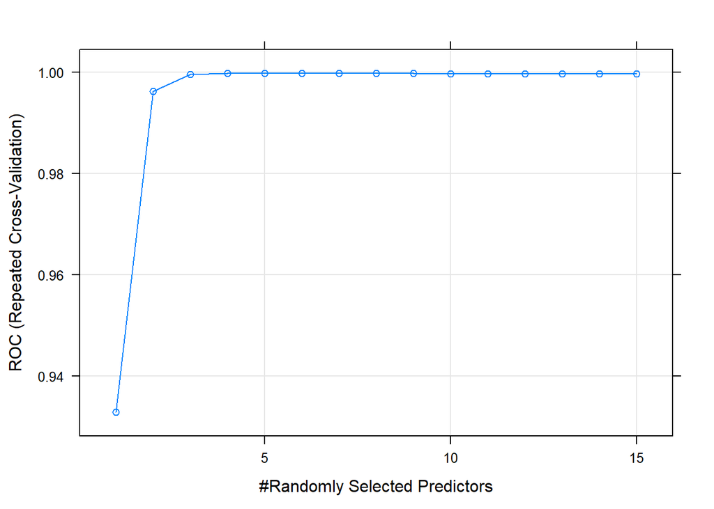

```
## [1] "Cruva ROC:"
```

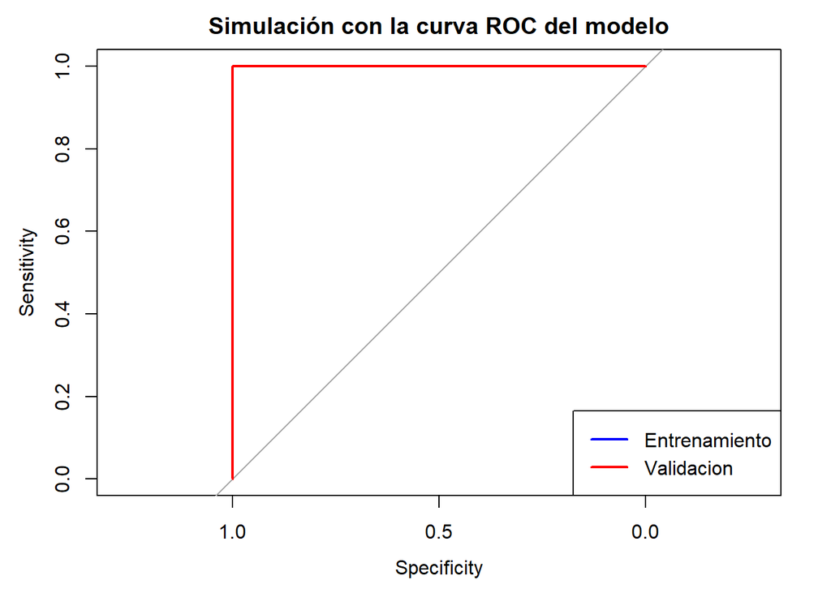

```r
plot_roc_curve(rf.fit)
```